# Lesson 3

### Moira’s Investigation

Notes:

### Estimating Your Audience Size

Notes:

- most people underestimated the audience size

#### Think about a time when you posted a specific message or shared a photo on Facebook. What was it?

Response: I don’t use Facebook.

#### How many of your friends do you think saw that post?

Response: 0

#### Think about what percent of your friends on Facebook see any posts or comments that you make in a month. What percent do you think that is?

Response: 0

### Perceived Audience Size

Notes:

- The preliminary result of underestimation in most cases is interesting.

### Faceting

Notes:

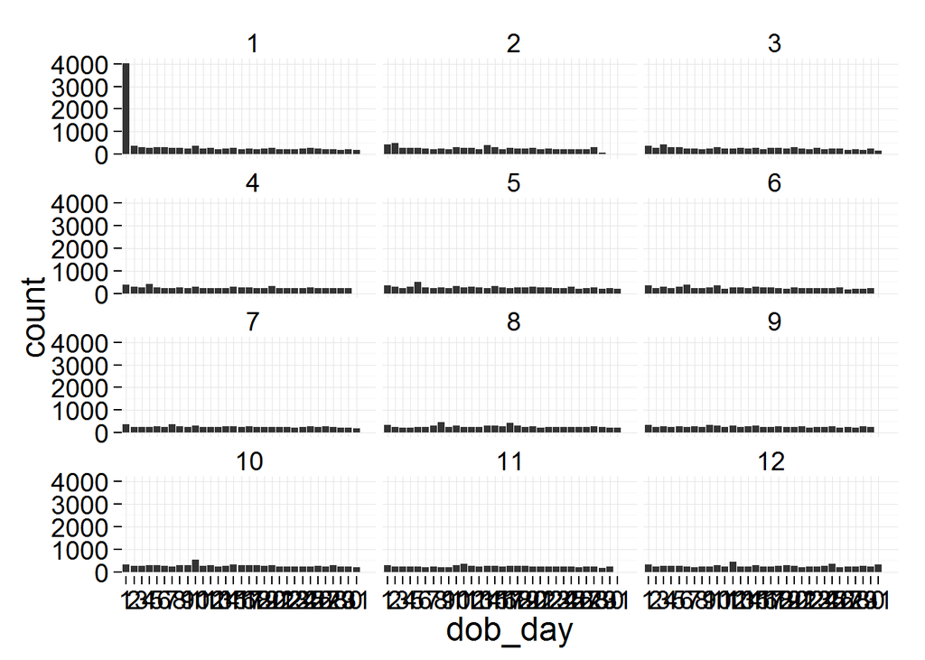

```r
qplot(x = dob_day, data = pf) +
    scale_x_discrete(breaks = 1:31) +
    facet_wrap(~ dob_month, ncol=3)
```

#### Let’s take another look at our plot. What stands out to you here?

Response: The excess 1’s seem to be in January.

### Be Skeptical - Outliers and Anomalies

Notes:

- Usually we have to go in depth to say if an outlier is a real case or not

### Moira’s Outlier

Notes:

- It’s unlikely that someone has 10 million friends.

#### Which case do you think applies to Moira’s outlier?

Response: bad data about an extreme case

### Friend Count

Notes:

#### What code would you enter to create a histogram of friend counts?

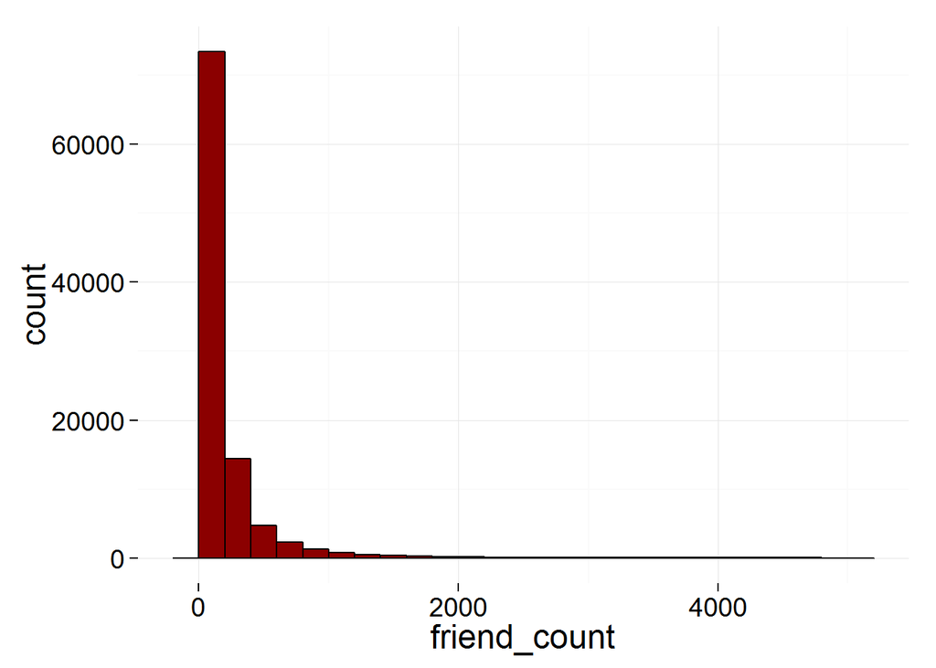

```r
ggplot(pf, aes(x = friend_count)) +
    geom_histogram(binwidth = 200, fill = "darkred", color = "black")
```

#### How is this plot similar to Moira’s first plot?

Response: It is similar because it is a distribution that looks like an exponential one with some outliers as well.

### Limiting the Axes

Notes:

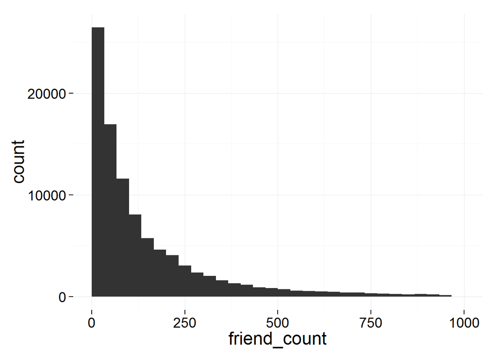

```r
qplot(x = friend_count, data = pf, xlim = c(0, 1000))
```

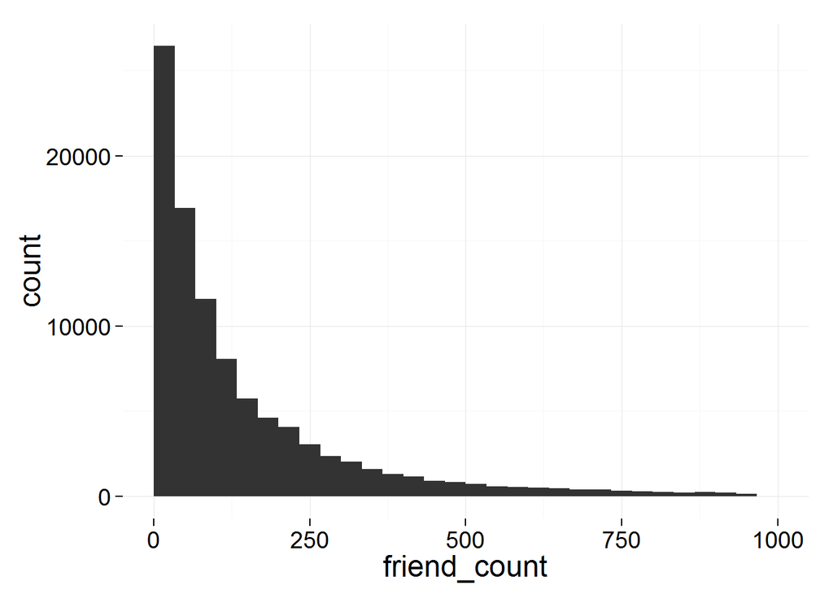

```r
qplot(x = friend_count, data = pf) +
    scale_x_continuous(limits=c(0, 1000))
```

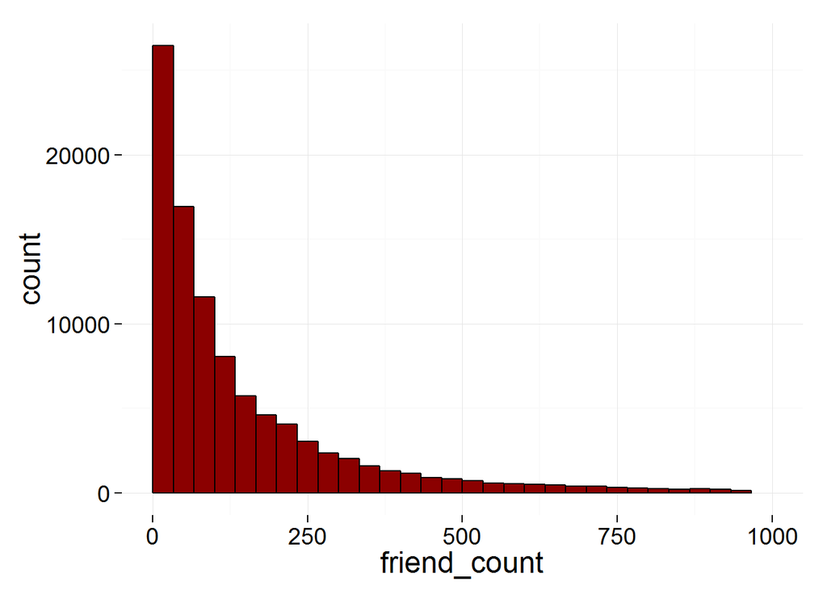

```r
ggplot(pf, aes(x = friend_count)) +
    geom_histogram(fill = "darkred", color = "black") +
    scale_x_continuous(limits=c(0, 1000))
```

### Exploring with Bin Width

Notes:

- Changing the bin width can reveal interesting patterns in the data.

### Adjusting the Bin Width

Notes:

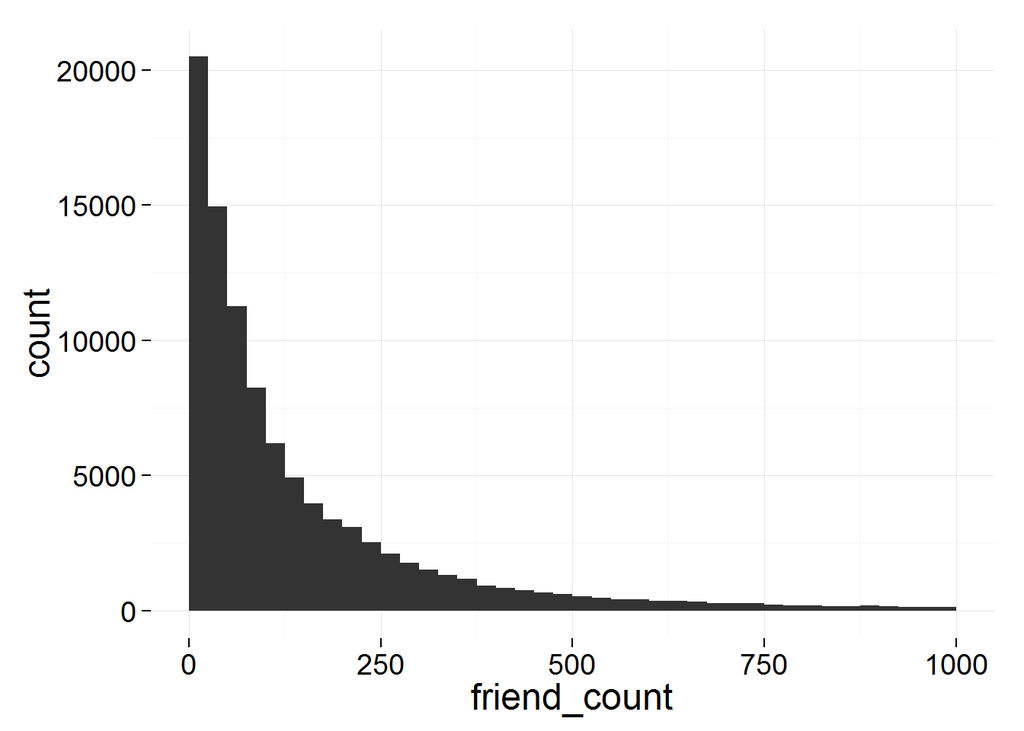

```r
qplot(x = friend_count, data = pf, binwidth = 25) +
    scale_x_continuous(limits=c(0, 1000))
```

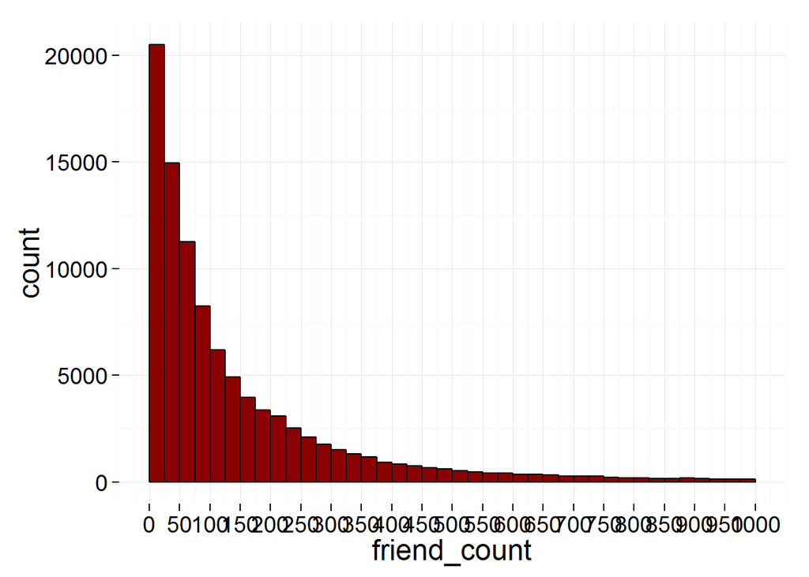

```r
ggplot(pf, aes(x = friend_count)) +
    geom_histogram(binwidth = 25, fill = "darkred", color = "black") +
    scale_x_continuous(limits = c(0, 1000), breaks = seq(0, 1000, 50))
```

### Faceting Friend Count

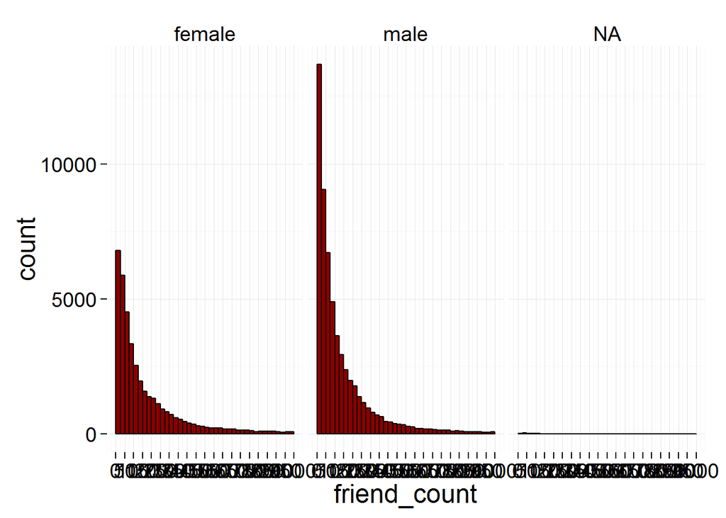

```r
# What code would you add to create a facet the histogram by gender?
# Add it to the code below.
ggplot(pf, aes(x = friend_count)) +
    geom_histogram(binwidth = 25, fill = "darkred", color = "black") +
    scale_x_continuous(limits = c(0, 1000), breaks = seq(0, 1000, 50)) +
    facet_wrap(~ gender)
```

### Omitting NA Values

Notes:

- NA is an encoding for missing values

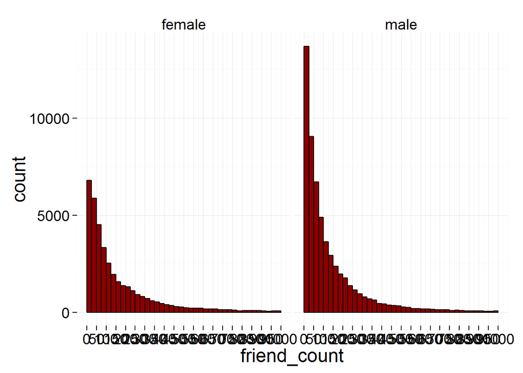

```r
ggplot(subset(pf, !is.na(gender)), aes(x = friend_count)) +
    geom_histogram(binwidth = 25, fill = "darkred", color = "black") +
    scale_x_continuous(limits = c(0, 1000), breaks = seq(0, 1000, 50)) +
    facet_wrap(~ gender)
```

### Statistics ‘by’ Gender

Notes:

- those histograms don’t really answer the question because there might be mre men than women

```r
table(pf$gender)
```

```
##
## female   male
##  40254  58574
```

```r
by(pf$friend_count, pf$gender, summary)
```

```
## pf$gender: female
##    Min. 1st Qu.  Median    Mean 3rd Qu.    Max.
##       0      37      96     242     244    4923
## --------------------------------------------------------
## pf$gender: male
##    Min. 1st Qu.  Median    Mean 3rd Qu.    Max.
##       0      27      74     165     182    4917
```

#### Who on average has more friends: men or women?

Response: women

#### What’s the difference between the median friend count for women and men?

Response: 22

#### Why would the median be a better measure than the mean?

Response: Because the distributions are very skewed.

### Tenure

Notes:

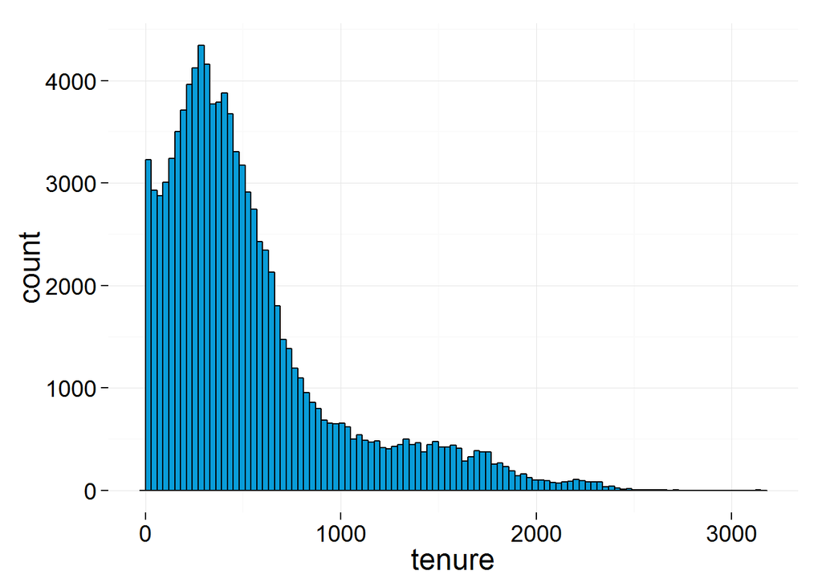

```r
ggplot(aes(x = tenure), data = pf) +
    geom_histogram(binwidth = 30, color = 'black', fill = '#099DD9')
```

#### How would you create a histogram of tenure by year?

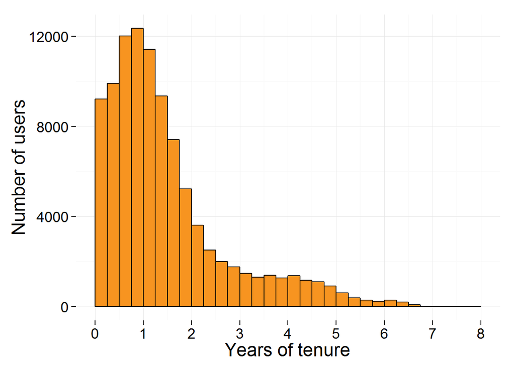

```r
ggplot(aes(x = tenure / 365), data = pf) +
    scale_x_continuous(limits = c(0, 8), breaks = seq(0, 8, 1)) +
    geom_histogram(binwidth = 0.25, color = 'black', fill = '#F79420') +
    xlab("Years of tenure") +
    ylab("Number of users")
```

### Labeling Plots

Notes:

- The plots should speak for themselves

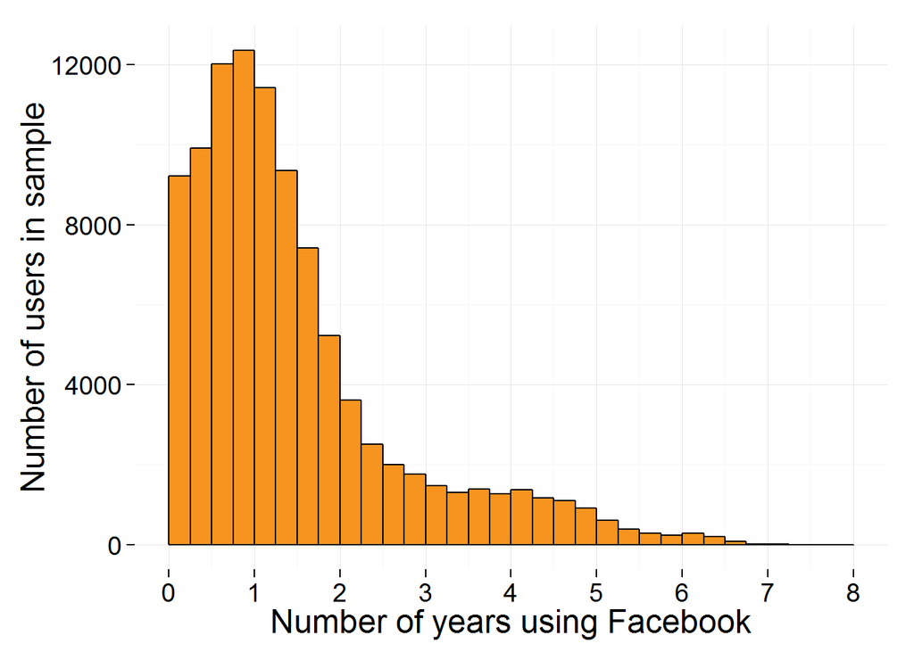

```r
ggplot(aes(x = tenure / 365), data = pf) +
    xlab("Number of years using Facebook") +
    ylab("Number of users in sample") +
    scale_x_continuous(limits = c(0, 8), breaks = seq(0, 8, 1)) +
    geom_histogram(binwidth = 0.25, color = 'black', fill = '#F79420')
```

### User Ages

Notes:

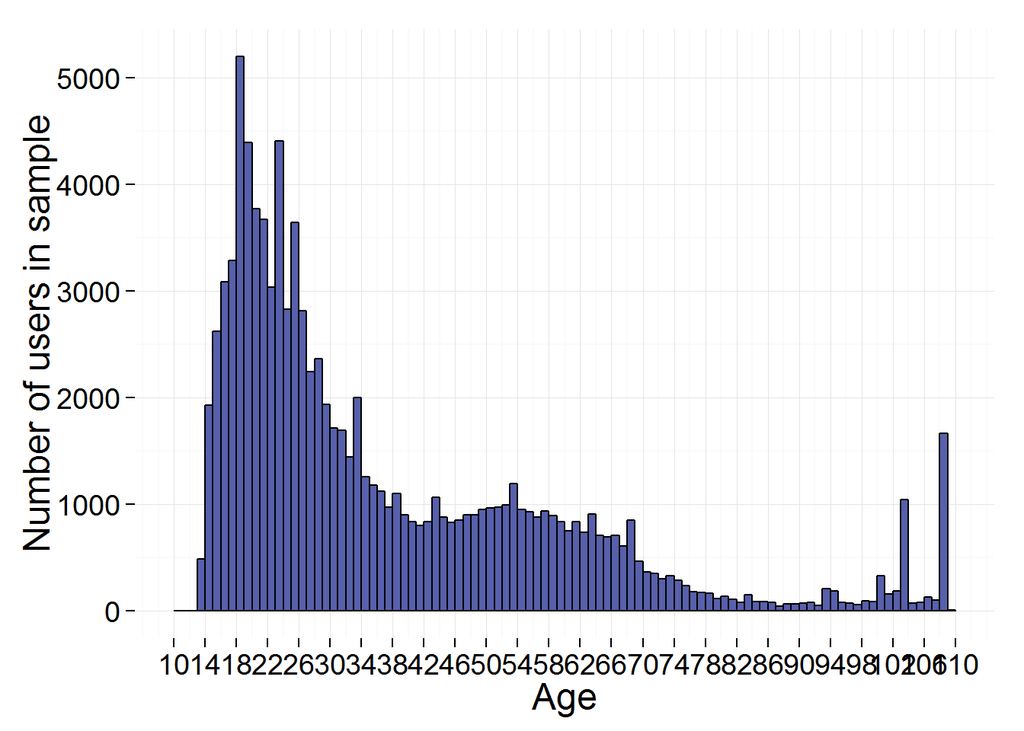

```r
ggplot(aes(x = age), data = pf) +
    xlab("Age") +
    ylab("Number of users in sample") +
    scale_x_continuous(limits = c(10, 110), breaks = seq(10, 110, 4)) +
    geom_histogram(binwidth = 1, color = 'black', fill = '#5760AB')
```

#### What do you notice?

Response: By far the most users are in the 18-20 years range.

### The Spread of Memes

Notes:

- The finding that memes never truly disappear is very interesting.

### Lada’s Money Bag Meme

Notes:

### Transforming Data

Notes:

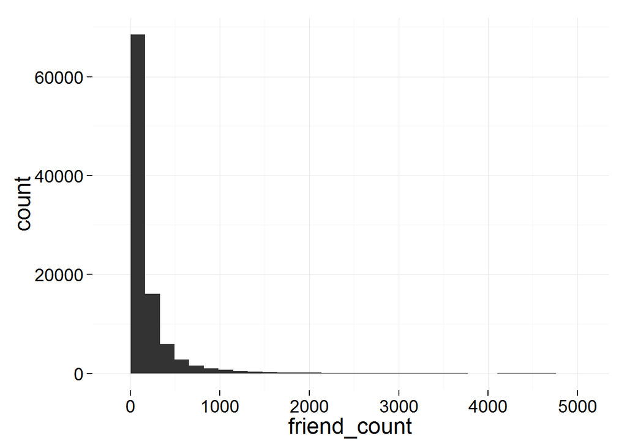

```r
qplot(x = friend_count, data = pf)
```

```r
summary(pf$friend_count)
```

```
##    Min. 1st Qu.  Median    Mean 3rd Qu.    Max.
##     0.0    31.0    82.0   196.4   206.0  4923.0
```

```r
summary(log10(pf$friend_count + 1))
```

```
##    Min. 1st Qu.  Median    Mean 3rd Qu.    Max.
##   0.000   1.505   1.919   1.868   2.316   3.692
```

```r
summary(sqrt(pf$friend_count + 1))
```

```
##    Min. 1st Qu.  Median    Mean 3rd Qu.    Max.
##   1.000   5.657   9.110  11.180  14.390  70.170
```

```r
#install.packages('gridExtra')
library(gridExtra)
```

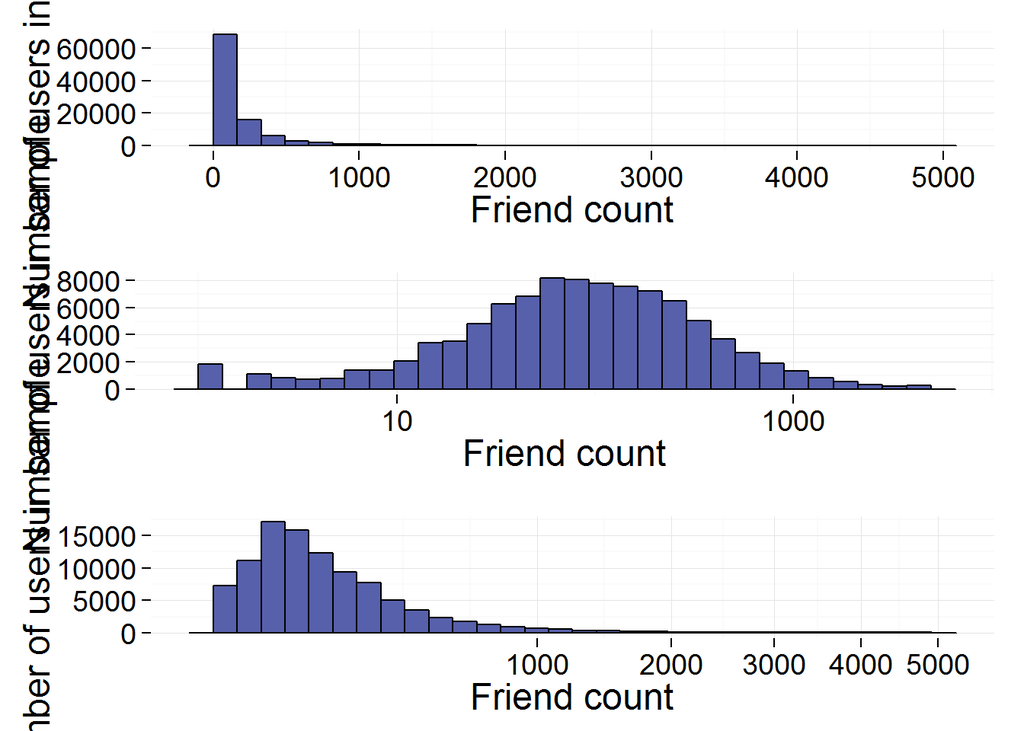

```r
p1 <- ggplot(aes(x = friend_count), data = pf) +
    xlab("Friend count") +
    ylab("Number of users in sample") +
    geom_histogram(color = 'black', fill = '#5760AB')
p2 <- p1 + scale_x_log10()
p3 <- p1 + scale_x_sqrt()

grid.arrange(p1, p2, p3, ncol = 1)
```

### Add a Scaling Layer

Notes:

- scales can be added to existing plots(DRY)
- be careful with the axis names when adding scales

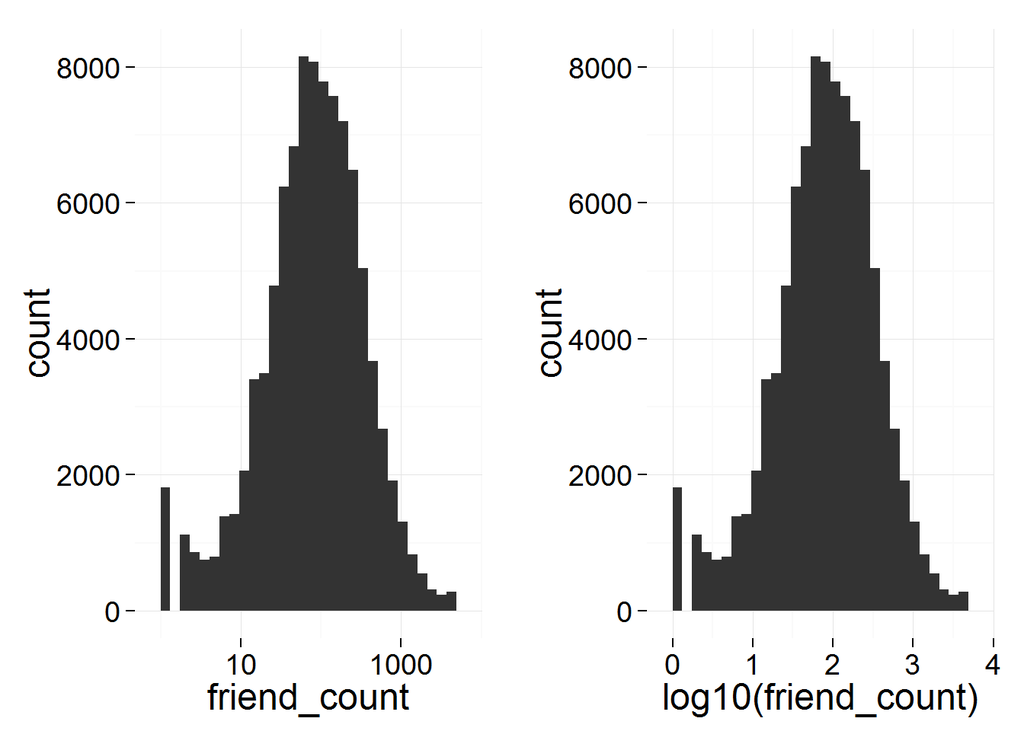

```r
countScale <- ggplot(aes(x = friend_count), data = pf) +
    geom_histogram() +
    scale_x_log10()

logScale <- qplot(x = log10(friend_count), data = pf)

grid.arrange(countScale, logScale, ncol = 2)
```

### Frequency Polygons

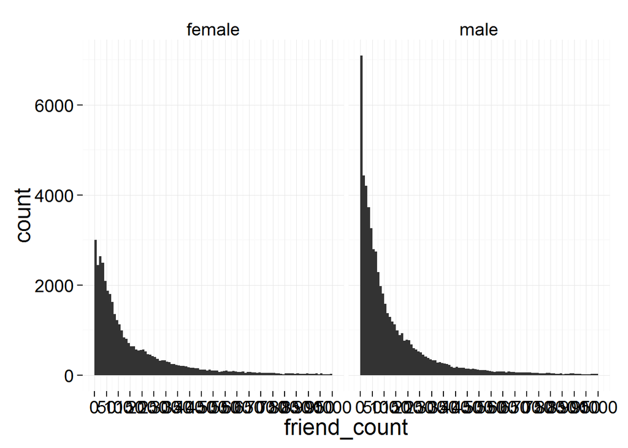

```r
qplot(x = friend_count, data = subset(pf, !is.na(gender)), binwidth = 10) +
    scale_x_continuous(limits = c(0, 1000), breaks = seq(0, 1000, 50)) +
    facet_wrap(~ gender)
```

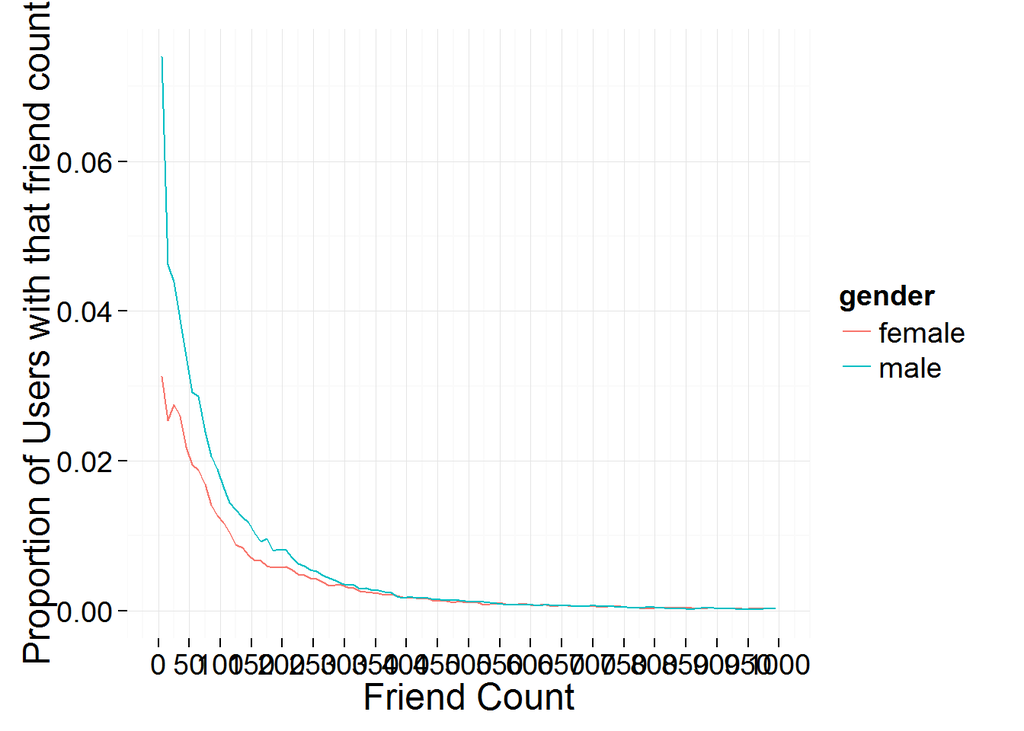

```r
qplot(x = friend_count, y = ..count../sum(..count..),
      data = subset(pf, !is.na(gender)),
      xlab = "Friend Count",
      ylab = "Proportion of Users with that friend count",
      geom = "freqpoly", binwidth = 10, color = gender) +
    scale_x_continuous(limits = c(0, 1000), breaks = seq(0, 1000, 50))
```

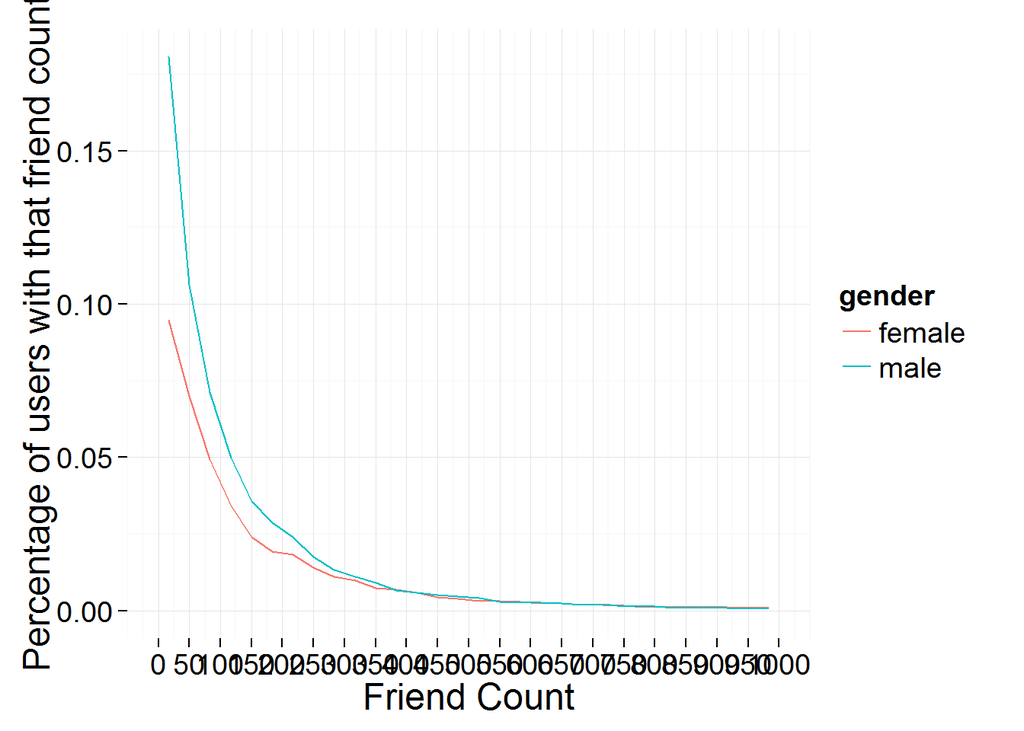

```r
ggplot(aes(x = friend_count, y = ..count../sum(..count..)), data = subset(pf, !is.na(gender))) +
    geom_freqpoly(aes(color = gender)) +
    scale_x_continuous(limits = c(0, 1000), breaks = seq(0, 1000, 50)) +
    xlab('Friend Count') +
    ylab('Percentage of users with that friend count')
```

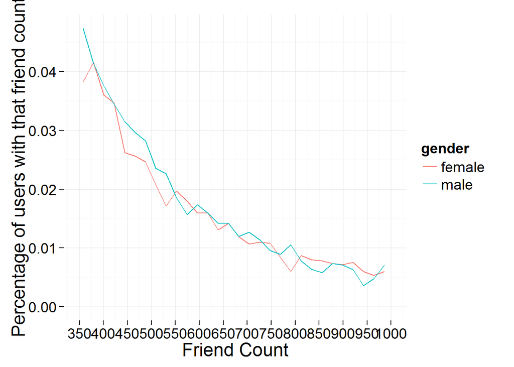

```r
ggplot(aes(x = friend_count, y = ..count../sum(..count..)), data = subset(pf, !is.na(gender))) +
    geom_freqpoly(aes(color = gender)) +
    scale_x_continuous(limits = c(350, 1000), breaks = seq(350, 1000, 50)) +
    xlab('Friend Count') +
    ylab('Percentage of users with that friend count')
```

### Likes on the Web

Notes:

- the ticks on the log scale are from the normal plot

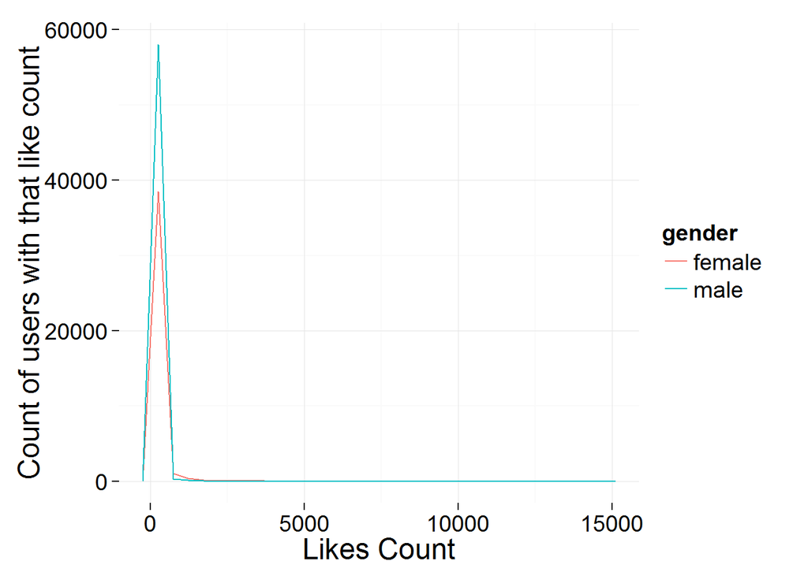

```r
ggplot(aes(x = www_likes), data = subset(pf, !is.na(gender))) +
    geom_freqpoly(aes(color = gender)) +
    scale_x_continuous() +
    xlab('Likes Count') +
    ylab('Count of users with that like count')
```

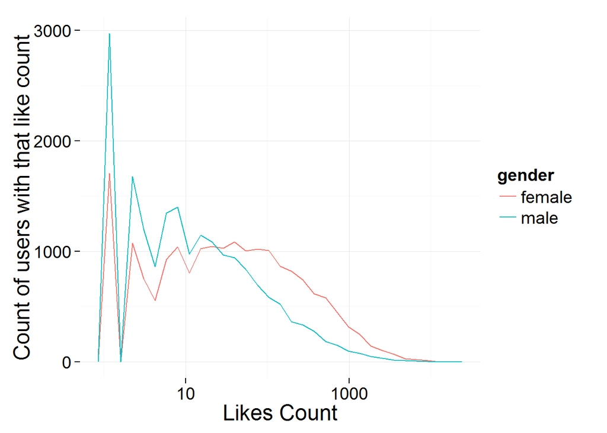

```r
ggplot(aes(x = www_likes), data = subset(pf, !is.na(gender))) +
    geom_freqpoly(aes(color = gender)) +
    scale_x_log10() +
    xlab('Likes Count') +
    ylab('Count of users with that like count')
```

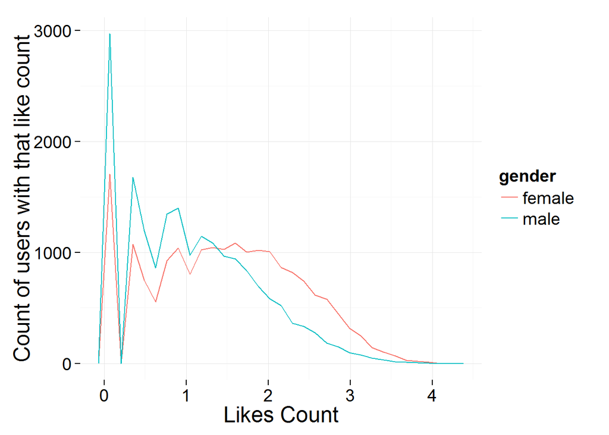

```r
ggplot(aes(x = log10(www_likes)), data = subset(pf, !is.na(gender))) +
    geom_freqpoly(aes(color = gender)) +
    scale_x_continuous()+
    xlab('Likes Count') +
    ylab('Count of users with that like count')
```

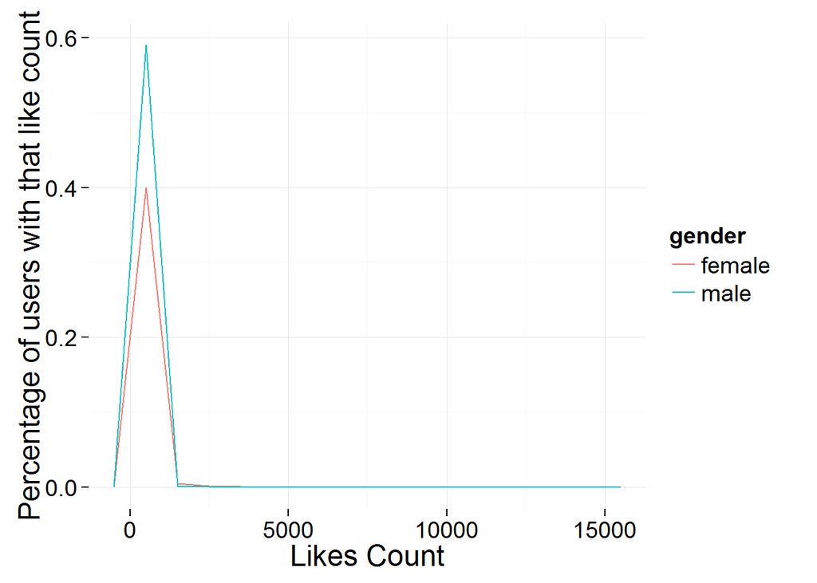

```r
ggplot(aes(x = www_likes, y = ..count../sum(..count..)), data = subset(pf, !is.na(gender))) +
    geom_freqpoly(aes(color = gender), binwidth = 1000) +
    scale_x_continuous() +
    xlab('Likes Count') +
    ylab('Percentage of users with that like count')
```

### Box Plots

Notes:

- box plots are an alternative to faceted histograms

```r
by(pf$www_likes, pf$gender, sum)
```

```
## pf$gender: female
## [1] 3507665
## --------------------------------------------------------
## pf$gender: male
## [1] 1430175
```

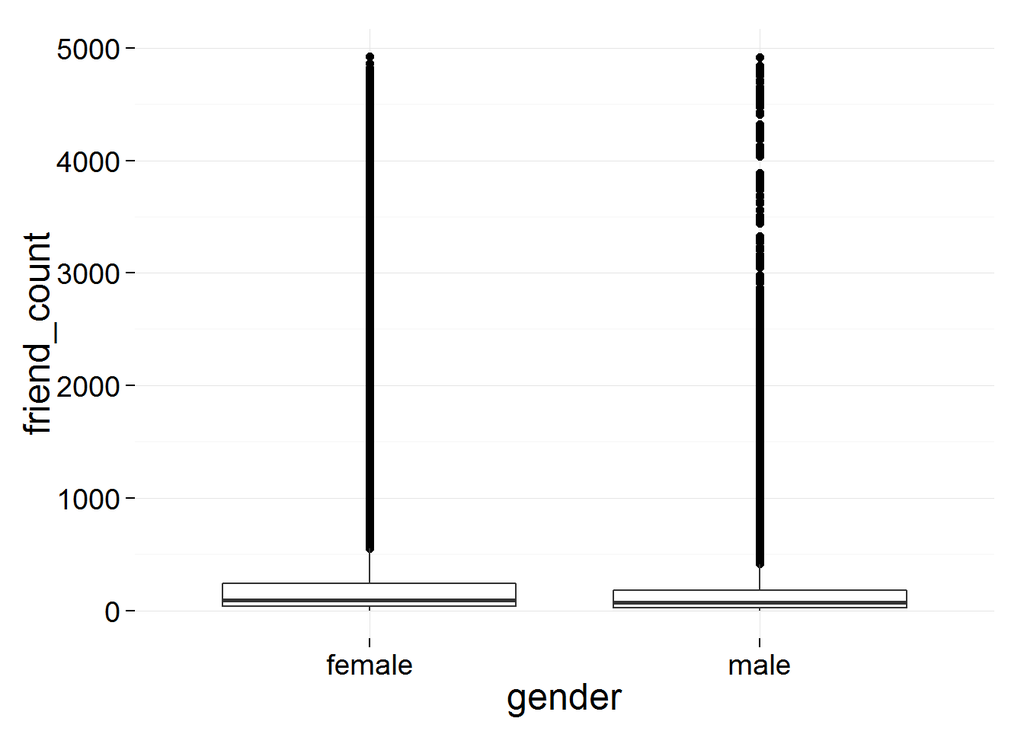

```r
ggplot(subset(pf, !is.na(gender)), aes(x = gender, y = friend_count)) +
    geom_boxplot()
```

#### Adjust the code to focus on users who have friend counts between 0 and 1000.

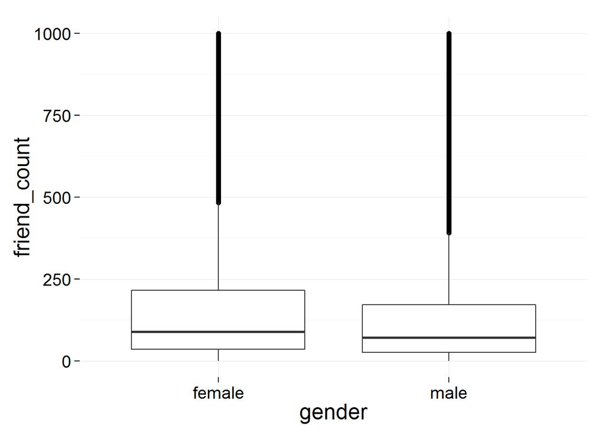

```r
ggplot(subset(pf, !is.na(gender)), aes(x = gender, y = friend_count)) +
    geom_boxplot() +
    scale_y_continuous(limits = c(0, 1000))
```

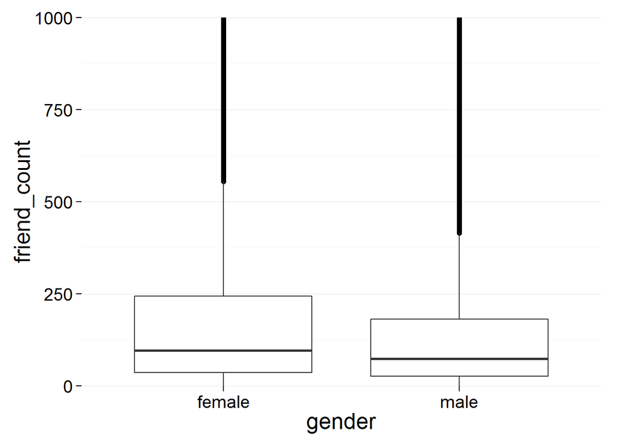

```r
# scale_y_continuous removes data points from calculations; use coord_cartesian instead
ggplot(subset(pf, !is.na(gender)), aes(x = gender, y = friend_count)) +
    geom_boxplot() +
    coord_cartesian(ylim = c(0, 1000))
```

### Box Plots, Quartiles, and Friendships

Notes:

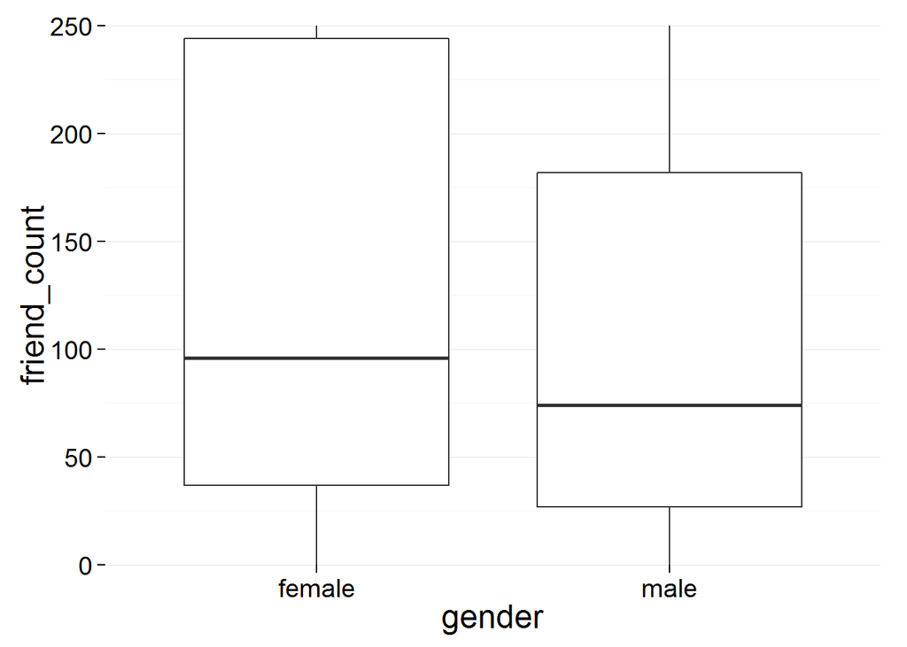

```r
ggplot(subset(pf, !is.na(gender)), aes(x = gender, y = friend_count)) +
    geom_boxplot() +
    coord_cartesian(ylim = c(0, 250))
```

```r
by(pf$friend_count, pf$gender, summary)
```

```
## pf$gender: female
##    Min. 1st Qu.  Median    Mean 3rd Qu.    Max.
##       0      37      96     242     244    4923
## --------------------------------------------------------
## pf$gender: male
##    Min. 1st Qu.  Median    Mean 3rd Qu.    Max.
##       0      27      74     165     182    4917
```

#### On average, who initiated more friendships in our sample: men or women?

```r
by(pf$friendships_initiated, pf$gender, summary)
```

```
## pf$gender: female
##    Min. 1st Qu.  Median    Mean 3rd Qu.    Max.
##     0.0    19.0    49.0   113.9   124.8  3654.0
## --------------------------------------------------------
## pf$gender: male
##    Min. 1st Qu.  Median    Mean 3rd Qu.    Max.
##     0.0    15.0    44.0   103.1   111.0  4144.0
```

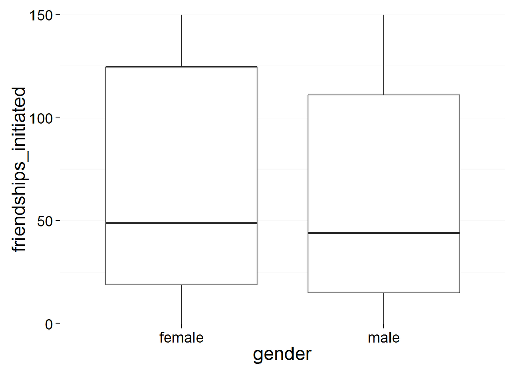

```r
ggplot(subset(pf, !is.na(gender)), aes(x = gender, y = friendships_initiated)) +
    geom_boxplot() +
    coord_cartesian(ylim = c(0, 150))
```

Response:

### Getting Logical

Notes:

```r
summary(pf$mobile_likes)
```

```
##    Min. 1st Qu.  Median    Mean 3rd Qu.    Max.
##     0.0     0.0     4.0   106.1    46.0 25110.0
```

```r
table(pf$mobile_likes > 0)
```

```
##
## FALSE  TRUE
## 35056 63947
```

```r
pf$mobile_check_in <- ifelse(pf$mobile_likes > 0, 1, 0)
pf$mobile_check_in <- as.factor(pf$mobile_check_in)
summary(pf$mobile_check_in)
```

```
##     0     1
## 35056 63947
```

```r
mean(pf$mobile_check_in == "1") * 100
```

```
## [1] 64.59097
```

Response:

### Analyzing One Variable

Reflection:

Click **KnitHTML** to see all of your hard work and to have an html page of this lesson, your answers, and your notes!